# STA 141B Assignment 5

Due **Mar 4, 2019** by 11:59pm. Submit by editing this file, committing the changes with git, and then pushing to your private GitHub repo for the assignment. This assignment will be graded according to the class rubric.

Please do not rename this file or delete the exercise cells, because it will interfere with our grading tools. Put your answers in new cells after each exercise. You can make as many new cells as you like. Use code cells for code and Markdown cells for text. Answer all questions with complete sentences.

The purpose of this assignment is to practice accessing and analyzing data in a database.

**For full credit, do most of your work in SQL.** Subsetting, sorting, grouping, aggregation, and merging can all be done in SQL. It is okay to use Python code for parts of your analysis that are difficult or impossible to do in SQL, such as creating visualizations or computing statistics (other than the mean).

## Lahman's Baseball Database

In this assignment, you'll use SQL queries and **pandas** to explore data in [Lahman's Baseball Database](http://www.seanlahman.com/baseball-archive/statistics/), which contains "complete batting and pitching statistics from 1871 to 2018, plus fielding statistics, standings, team stats, managerial records, post-season data, and more."

You can download the database in SQLite format [HERE](https://anson.ucdavis.edu/~nulle/baseball.sqlite).

Documentation for the database, including a description of all tables, is in the `README.md` file included in this repository.

**Exercise 1.1.**

1. From 2006 to 2016, which 5 teams had the highest payrolls? Payroll means the sum of the salaries for all people on the team in a given year.
2. Is there any general trend in payrolls over this time period?
3. There are at least 2 anomalies in the payrolls over this time period. What are they, and can you find information (online or elsewhere) to explain them?
4. How do the top 5 teams compare to other teams?

```python
import numpy as np
import pandas as pd
import sqlite3 as sql
import seaborn as sns;
db = sql.connect("baseball.sqlite")
```

```python
# 2006 summed salary table
pd.read_sql("SELECT yearID,teamID,lgID , SUM(salary) AS sumsalary FROM Salaries WHERE yearID= 2006 GROUP BY teamID,lgID  ORDER BY sumsalary;", db)
```

|  | yearID | teamID | lgID | sumsalary |
| --- | --- | --- | --- | --- |
| 0 | 2006 | FLO | NL | 14671500 |
| 1 | 2006 | TBA | AL | 34917967 |
| 2 | 2006 | COL | NL | 41233000 |
| 3 | 2006 | PIT | NL | 46717750 |
| 4 | 2006 | KCA | AL | 47294000 |
| 5 | 2006 | CLE | AL | 56031500 |
| 6 | 2006 | MIL | NL | 57568333 |
| 7 | 2006 | ARI | NL | 59684226 |
| 8 | 2006 | CIN | NL | 60909519 |
| 9 | 2006 | OAK | AL | 62243079 |
| 10 | 2006 | WAS | NL | 63143000 |
| 11 | 2006 | MIN | AL | 63396006 |
| 12 | 2006 | TEX | AL | 68228662 |
| 13 | 2006 | SDN | NL | 69896141 |
| 14 | 2006 | TOR | AL | 71365000 |
| 15 | 2006 | BAL | AL | 72585582 |
| 16 | 2006 | DET | AL | 82612866 |
| 17 | 2006 | SEA | AL | 87959833 |
| 18 | 2006 | PHI | NL | 88273333 |
| 19 | 2006 | HOU | NL | 88694435 |
| 20 | 2006 | SLN | NL | 88891371 |
| 21 | 2006 | SFN | NL | 90056419 |
| 22 | 2006 | ATL | NL | 90156876 |
| 23 | 2006 | CHN | NL | 94424499 |
| 24 | 2006 | LAN | NL | 98447187 |
| 25 | 2006 | NYN | NL | 101084963 |
| 26 | 2006 | CHA | AL | 102750667 |
| 27 | 2006 | LAA | AL | 103472000 |
| 28 | 2006 | BOS | AL | 120099824 |
| 29 | 2006 | NYA | AL | 194663079 |

```python
team2006=["NYA","BOS","LAA","CHA","NYN"]
```

```python
# 2007 summed salary table
pd.read_sql("SELECT yearID,teamID,lgID , SUM(salary) AS sumsalary FROM Salaries WHERE yearID= 2007 GROUP BY teamID,lgID  ORDER BY sumsalary;", db)
```

|  | yearID | teamID | lgID | sumsalary |
| --- | --- | --- | --- | --- |
| 0 | 2007 | TBA | AL | 24123500 |
| 1 | 2007 | FLO | NL | 30507000 |
| 2 | 2007 | WAS | NL | 36947500 |
| 3 | 2007 | PIT | NL | 38537833 |
| 4 | 2007 | ARI | NL | 52067546 |
| 5 | 2007 | COL | NL | 54041000 |
| 6 | 2007 | SDN | NL | 58110567 |
| 7 | 2007 | CLE | AL | 61673267 |
| 8 | 2007 | KCA | AL | 67116500 |
| 9 | 2007 | TEX | AL | 68318675 |
| 10 | 2007 | CIN | NL | 68524980 |
| 11 | 2007 | MIL | NL | 70986500 |
| 12 | 2007 | MIN | AL | 71439500 |
| 13 | 2007 | OAK | AL | 79366940 |
| 14 | 2007 | TOR | AL | 81942800 |
| 15 | 2007 | ATL | NL | 87290833 |
| 16 | 2007 | HOU | NL | 87759000 |
| 17 | 2007 | PHI | NL | 89428213 |
| 18 | 2007 | SFN | NL | 90219056 |
| 19 | 2007 | SLN | NL | 90286823 |
| 20 | 2007 | BAL | AL | 93174808 |
| 21 | 2007 | DET | AL | 94800369 |
| 22 | 2007 | CHN | NL | 99670332 |
| 23 | 2007 | SEA | AL | 106460833 |
| 24 | 2007 | LAN | NL | 108454524 |
| 25 | 2007 | CHA | AL | 108671833 |
| 26 | 2007 | LAA | AL | 109251333 |
| 27 | 2007 | NYN | NL | 115231663 |
| 28 | 2007 | BOS | AL | 143026214 |
| 29 | 2007 | NYA | AL | 189259045 |

```python
team2007=["NYA","BOS","LAA","CHA","NYN"]
```

```python
# 2008 summed salary table
pd.read_sql("SELECT yearID,teamID,lgID , SUM(salary) AS sumsalary FROM Salaries WHERE yearID= 2008 GROUP BY teamID,lgID  ORDER BY sumsalary;", db)
```

|  | yearID | teamID | lgID | sumsalary |
| --- | --- | --- | --- | --- |
| 0 | 2008 | FLO | NL | 21811500 |
| 1 | 2008 | TBA | AL | 43820597 |
| 2 | 2008 | OAK | AL | 47967126 |
| 3 | 2008 | PIT | NL | 48689783 |
| 4 | 2008 | WAS | NL | 54961000 |
| 5 | 2008 | MIN | AL | 56932766 |
| 6 | 2008 | KCA | AL | 58245500 |
| 7 | 2008 | ARI | NL | 66202712 |
| 8 | 2008 | BAL | AL | 67196246 |
| 9 | 2008 | TEX | AL | 67712326 |
| 10 | 2008 | COL | NL | 68655500 |
| 11 | 2008 | SDN | NL | 73677616 |
| 12 | 2008 | CIN | NL | 74117695 |
| 13 | 2008 | SFN | NL | 76594500 |
| 14 | 2008 | CLE | AL | 78970066 |
| 15 | 2008 | MIL | NL | 80937499 |
| 16 | 2008 | HOU | NL | 88930414 |
| 17 | 2008 | TOR | AL | 97793900 |
| 18 | 2008 | PHI | NL | 97879880 |
| 19 | 2008 | SLN | NL | 99624449 |
| 20 | 2008 | ATL | NL | 102365683 |
| 21 | 2008 | SEA | AL | 117666482 |
| 22 | 2008 | CHN | NL | 118345833 |
| 23 | 2008 | LAN | NL | 118588536 |
| 24 | 2008 | LAA | AL | 119216333 |
| 25 | 2008 | CHA | AL | 121189332 |
| 26 | 2008 | BOS | AL | 133390035 |
| 27 | 2008 | DET | AL | 137685196 |
| 28 | 2008 | NYN | NL | 137793376 |
| 29 | 2008 | NYA | AL | 207896789 |

```python
team2008=["NYA","BOS","DET","CHA","NYN"]
```

```python
# 2009 summed salary table
pd.read_sql("SELECT yearID,teamID,lgID , SUM(salary) AS sumsalary FROM Salaries WHERE yearID= 2009 GROUP BY teamID,lgID  ORDER BY sumsalary;", db)
```

|  | yearID | teamID | lgID | sumsalary |
| --- | --- | --- | --- | --- |
| 0 | 2009 | FLO | NL | 36834000 |
| 1 | 2009 | SDN | NL | 43333700 |
| 2 | 2009 | PIT | NL | 48693000 |
| 3 | 2009 | WAS | NL | 59928000 |
| 4 | 2009 | OAK | AL | 61910000 |
| 5 | 2009 | TBA | AL | 63313034 |
| 6 | 2009 | MIN | AL | 65299266 |
| 7 | 2009 | BAL | AL | 67101666 |
| 8 | 2009 | TEX | AL | 68178798 |
| 9 | 2009 | KCA | AL | 70519333 |
| 10 | 2009 | ARI | NL | 73115666 |
| 11 | 2009 | CIN | NL | 73558500 |
| 12 | 2009 | COL | NL | 75201000 |
| 13 | 2009 | MIL | NL | 80182502 |
| 14 | 2009 | TOR | AL | 80538300 |
| 15 | 2009 | CLE | AL | 81579166 |
| 16 | 2009 | SFN | NL | 83026450 |
| 17 | 2009 | SLN | NL | 88528409 |
| 18 | 2009 | CHA | AL | 96068500 |
| 19 | 2009 | ATL | NL | 96726166 |
| 20 | 2009 | SEA | AL | 98904166 |
| 21 | 2009 | LAN | NL | 100414592 |
| 22 | 2009 | HOU | NL | 102996414 |
| 23 | 2009 | PHI | NL | 113004046 |
| 24 | 2009 | LAA | AL | 113709000 |
| 25 | 2009 | DET | AL | 115085145 |
| 26 | 2009 | BOS | AL | 121345999 |
| 27 | 2009 | CHN | NL | 134809000 |
| 28 | 2009 | NYN | NL | 149373987 |
| 29 | 2009 | NYA | AL | 201449189 |

```python
team2009=["NYA","BOS","DET","CHA","NYN"]
```

```python
# 2010 summed salary table
pd.read_sql("SELECT yearID,teamID,lgID , SUM(salary) AS sumsalary FROM Salaries WHERE yearID= 2010 GROUP BY teamID,lgID  ORDER BY sumsalary;", db)
```

|  | yearID | teamID | lgID | sumsalary |
| --- | --- | --- | --- | --- |
| 0 | 2010 | PIT | NL | 34943000 |
| 1 | 2010 | SDN | NL | 37799300 |
| 2 | 2010 | TEX | AL | 55250544 |
| 3 | 2010 | OAK | AL | 55254900 |
| 4 | 2010 | FLO | NL | 57029719 |
| 5 | 2010 | ARI | NL | 60718166 |
| 6 | 2010 | CLE | AL | 61203966 |
| 7 | 2010 | WAS | NL | 61400000 |
| 8 | 2010 | TOR | AL | 62234000 |
| 9 | 2010 | KCA | AL | 71405210 |
| 10 | 2010 | CIN | NL | 71761542 |
| 11 | 2010 | TBA | AL | 71923471 |
| 12 | 2010 | MIL | NL | 81108278 |
| 13 | 2010 | BAL | AL | 81612500 |
| 14 | 2010 | COL | NL | 84227000 |
| 15 | 2010 | ATL | NL | 84423666 |
| 16 | 2010 | SEA | AL | 86510000 |
| 17 | 2010 | HOU | NL | 92355500 |
| 18 | 2010 | SLN | NL | 93540751 |
| 19 | 2010 | LAN | NL | 95358016 |
| 20 | 2010 | MIN | AL | 97559166 |
| 21 | 2010 | SFN | NL | 98641333 |
| 22 | 2010 | LAA | AL | 104963866 |
| 23 | 2010 | CHA | AL | 105530000 |
| 24 | 2010 | DET | AL | 122864928 |
| 25 | 2010 | NYN | NL | 134422942 |
| 26 | 2010 | PHI | NL | 141928379 |
| 27 | 2010 | CHN | NL | 146609000 |
| 28 | 2010 | BOS | AL | 162447333 |
| 29 | 2010 | NYA | AL | 206333389 |

```python
team2010=["NYA","BOS","CHN","PHI","NYN"]
```

```python
# 2011 summed salary table
pd.read_sql("SELECT yearID,teamID,lgID , SUM(salary) AS sumsalary FROM Salaries WHERE yearID= 2011 GROUP BY teamID,lgID  ORDER BY sumsalary;", db)
```

|  | yearID | teamID | lgID | sumsalary |
| --- | --- | --- | --- | --- |
| 0 | 2011 | KCA | AL | 35712000 |
| 1 | 2011 | TBA | AL | 41053571 |
| 2 | 2011 | PIT | NL | 45047000 |
| 3 | 2011 | SDN | NL | 45869140 |
| 4 | 2011 | CLE | AL | 48776566 |
| 5 | 2011 | ARI | NL | 53639833 |
| 6 | 2011 | FLO | NL | 56944000 |
| 7 | 2011 | TOR | AL | 62567800 |
| 8 | 2011 | WAS | NL | 63856928 |
| 9 | 2011 | OAK | AL | 66536500 |
| 10 | 2011 | HOU | NL | 70694000 |
| 11 | 2011 | CIN | NL | 75947134 |
| 12 | 2011 | BAL | AL | 85304038 |
| 13 | 2011 | MIL | NL | 85497333 |
| 14 | 2011 | SEA | AL | 86110600 |
| 15 | 2011 | ATL | NL | 87002692 |
| 16 | 2011 | COL | NL | 88148071 |
| 17 | 2011 | TEX | AL | 92299264 |
| 18 | 2011 | LAN | NL | 104188999 |
| 19 | 2011 | SLN | NL | 105433572 |
| 20 | 2011 | DET | AL | 105700231 |
| 21 | 2011 | MIN | AL | 112737000 |
| 22 | 2011 | SFN | NL | 118198333 |
| 23 | 2011 | NYN | NL | 118847309 |
| 24 | 2011 | CHN | NL | 125047329 |
| 25 | 2011 | CHA | AL | 127789000 |
| 26 | 2011 | LAA | AL | 138543166 |
| 27 | 2011 | BOS | AL | 161762475 |
| 28 | 2011 | PHI | NL | 172976379 |
| 29 | 2011 | NYA | AL | 202275028 |

```python
team2011=["NYA","BOS","CHA","PHI","LAA"]
```

```python
# 2012 summed salary table
pd.read_sql("SELECT yearID,teamID,lgID , SUM(salary) AS sumsalary FROM Salaries WHERE yearID= 2012 GROUP BY teamID,lgID  ORDER BY sumsalary;", db)
```

|  | yearID | teamID | lgID | sumsalary |
| --- | --- | --- | --- | --- |
| 0 | 2012 | SDN | NL | 55244700 |
| 1 | 2012 | OAK | AL | 55372500 |
| 2 | 2012 | HOU | NL | 60651000 |
| 3 | 2012 | KCA | AL | 60916225 |
| 4 | 2012 | PIT | NL | 62951999 |
| 5 | 2012 | TBA | AL | 64173500 |
| 6 | 2012 | ARI | NL | 73804833 |
| 7 | 2012 | TOR | AL | 75009200 |
| 8 | 2012 | BAL | AL | 77353999 |
| 9 | 2012 | COL | NL | 78069571 |
| 10 | 2012 | CLE | AL | 78430300 |
| 11 | 2012 | WAS | NL | 80855143 |
| 12 | 2012 | SEA | AL | 81978100 |
| 13 | 2012 | CIN | NL | 82203616 |
| 14 | 2012 | ATL | NL | 82829942 |
| 15 | 2012 | CHN | NL | 88197033 |
| 16 | 2012 | NYN | NL | 93353983 |
| 17 | 2012 | MIN | AL | 94085000 |
| 18 | 2012 | LAN | NL | 95143575 |
| 19 | 2012 | CHA | AL | 96919500 |
| 20 | 2012 | MIL | NL | 97653944 |
| 21 | 2012 | SLN | NL | 110300862 |
| 22 | 2012 | SFN | NL | 117620683 |
| 23 | 2012 | MIA | NL | 118078000 |
| 24 | 2012 | TEX | AL | 120510974 |
| 25 | 2012 | DET | AL | 132300000 |
| 26 | 2012 | LAA | AL | 154485166 |
| 27 | 2012 | BOS | AL | 173186617 |
| 28 | 2012 | PHI | NL | 174538938 |
| 29 | 2012 | NYA | AL | 196522289 |

```python
team2012=["NYA","BOS","DET","PHI","LAA"]
```

```python
# 2013 summed salary table
pd.read_sql("SELECT yearID,teamID,lgID , SUM(salary) AS sumsalary FROM Salaries WHERE yearID= 2013 GROUP BY teamID,lgID  ORDER BY sumsalary;", db)
```

|  | yearID | teamID | lgID | sumsalary |
| --- | --- | --- | --- | --- |
| 0 | 2013 | HOU | AL | 17890700 |
| 1 | 2013 | MIA | NL | 33601900 |
| 2 | 2013 | NYN | NL | 49448346 |
| 3 | 2013 | TBA | AL | 52955272 |
| 4 | 2013 | OAK | AL | 60132500 |
| 5 | 2013 | SDN | NL | 65585500 |
| 6 | 2013 | SEA | AL | 74005043 |
| 7 | 2013 | COL | NL | 74409071 |
| 8 | 2013 | MIN | AL | 75337500 |
| 9 | 2013 | CLE | AL | 75771800 |
| 10 | 2013 | MIL | NL | 76947033 |
| 11 | 2013 | PIT | NL | 77062000 |
| 12 | 2013 | KCA | AL | 80091725 |
| 13 | 2013 | BAL | AL | 84393333 |
| 14 | 2013 | ATL | NL | 87871525 |
| 15 | 2013 | ARI | NL | 90132000 |
| 16 | 2013 | SLN | NL | 92260110 |
| 17 | 2013 | CHN | NL | 100567726 |
| 18 | 2013 | CIN | NL | 106404462 |
| 19 | 2013 | TEX | AL | 112522600 |
| 20 | 2013 | WAS | NL | 113703270 |
| 21 | 2013 | CHA | AL | 120065277 |
| 22 | 2013 | LAA | AL | 124174750 |
| 23 | 2013 | TOR | AL | 126288100 |
| 24 | 2013 | SFN | NL | 140180334 |
| 25 | 2013 | DET | AL | 145989500 |
| 26 | 2013 | BOS | AL | 151530000 |
| 27 | 2013 | PHI | NL | 169863189 |
| 28 | 2013 | LAN | NL | 223362196 |
| 29 | 2013 | NYA | AL | 231978886 |

```python
team2013=["NYA","LAN","PHI","BOS","DET"]
```

```python
# 2014 summed salary table
pd.read_sql("SELECT yearID,teamID,lgID , SUM(salary) AS sumsalary FROM Salaries WHERE yearID= 2014 GROUP BY teamID,lgID  ORDER BY sumsalary;", db)
```

|  | yearID | teamID | lgID | sumsalary |
| --- | --- | --- | --- | --- |
| 0 | 2014 | HOU | AL | 35116300 |
| 1 | 2014 | MIA | NL | 41836900 |
| 2 | 2014 | CHN | NL | 65522500 |
| 3 | 2014 | OAK | AL | 72408400 |
| 4 | 2014 | TBA | AL | 72689100 |
| 5 | 2014 | KCA | AL | 74594075 |
| 6 | 2014 | SDN | NL | 75685700 |
| 7 | 2014 | PIT | NL | 77178000 |
| 8 | 2014 | CHA | AL | 81830500 |
| 9 | 2014 | CLE | AL | 82151899 |
| 10 | 2014 | MIN | AL | 83762500 |
| 11 | 2014 | NYN | NL | 85556990 |
| 12 | 2014 | SEA | AL | 92531100 |
| 13 | 2014 | COL | NL | 95403500 |
| 14 | 2014 | ATL | NL | 97609000 |
| 15 | 2014 | ARI | NL | 97861500 |
| 16 | 2014 | MIL | NL | 101217000 |
| 17 | 2014 | BAL | AL | 103416000 |
| 18 | 2014 | CIN | NL | 108217500 |
| 19 | 2014 | TOR | AL | 109920100 |
| 20 | 2014 | TEX | AL | 112255059 |
| 21 | 2014 | SLN | NL | 120693000 |
| 22 | 2014 | LAA | AL | 121988250 |
| 23 | 2014 | WAS | NL | 131983680 |
| 24 | 2014 | BOS | AL | 139019929 |
| 25 | 2014 | DET | AL | 152855500 |
| 26 | 2014 | SFN | NL | 163510167 |
| 27 | 2014 | PHI | NL | 180944967 |
| 28 | 2014 | NYA | AL | 197543907 |
| 29 | 2014 | LAN | NL | 217014600 |

```python
team2014=["LAN","NYA","PHI","SFN","DET"]
```

```python
# 2015 summed salary table
pd.read_sql("SELECT yearID,teamID,lgID , SUM(salary) AS sumsalary FROM Salaries WHERE yearID= 2015 GROUP BY teamID,lgID  ORDER BY sumsalary;", db)
```

|  | yearID | teamID | lgID | sumsalary |
| --- | --- | --- | --- | --- |
| 0 | 2015 | ARI | NL | 61834000 |
| 1 | 2015 | TBA | AL | 64521233 |
| 2 | 2015 | MIA | NL | 68056500 |
| 3 | 2015 | ATL | NL | 71781250 |
| 4 | 2015 | HOU | AL | 72256200 |
| 5 | 2015 | OAK | AL | 79053501 |
| 6 | 2015 | CLE | AL | 87663766 |
| 7 | 2015 | PIT | NL | 88892499 |
| 8 | 2015 | COL | NL | 95688600 |
| 9 | 2015 | NYN | NL | 96766683 |
| 10 | 2015 | MIL | NL | 100850000 |
| 11 | 2015 | MIN | AL | 107755000 |
| 12 | 2015 | PHI | NL | 111693000 |
| 13 | 2015 | KCA | AL | 112107025 |
| 14 | 2015 | CHA | AL | 112373700 |
| 15 | 2015 | TOR | AL | 112992400 |
| 16 | 2015 | CIN | NL | 113072286 |
| 17 | 2015 | BAL | AL | 115044833 |
| 18 | 2015 | CHN | NL | 115879310 |
| 19 | 2015 | SDN | NL | 118441300 |
| 20 | 2015 | SLN | NL | 119241500 |
| 21 | 2015 | LAA | AL | 120005415 |
| 22 | 2015 | SEA | AL | 122208700 |
| 23 | 2015 | TEX | AL | 143742789 |
| 24 | 2015 | WAS | NL | 155587472 |
| 25 | 2015 | SFN | NL | 164701500 |
| 26 | 2015 | DET | AL | 172284750 |
| 27 | 2015 | BOS | AL | 181103400 |
| 28 | 2015 | NYA | AL | 212751957 |
| 29 | 2015 | LAN | NL | 215792000 |

```python
team2015=["LAN","NYA","BOS","DET","SFN"]
```

```python
# 2016 summed salary table
pd.read_sql("SELECT yearID,teamID,lgID , SUM(salary) AS sumsalary FROM Salaries WHERE yearID= 2016 GROUP BY teamID,lgID  ORDER BY sumsalary;", db)
```

|  | yearID | teamID | lgID | sumsalary |
| --- | --- | --- | --- | --- |
| 0 | 2016 | TBA | AL | 57097310 |
| 1 | 2016 | PHI | NL | 58980000 |
| 2 | 2016 | ATL | NL | 68498291 |
| 3 | 2016 | MIL | NL | 68775237 |
| 4 | 2016 | CLE | AL | 74311900 |
| 5 | 2016 | MIA | NL | 77314202 |
| 6 | 2016 | OAK | AL | 86806234 |
| 7 | 2016 | ARI | NL | 87439063 |
| 8 | 2016 | CIN | NL | 88940059 |
| 9 | 2016 | HOU | AL | 94893700 |
| 10 | 2016 | SDN | NL | 101424814 |
| 11 | 2016 | MIN | AL | 102583200 |
| 12 | 2016 | PIT | NL | 103778833 |
| 13 | 2016 | COL | NL | 112645071 |
| 14 | 2016 | CHA | AL | 112998667 |
| 15 | 2016 | KCA | AL | 131487125 |
| 16 | 2016 | NYN | NL | 133889129 |
| 17 | 2016 | SEA | AL | 135683339 |
| 18 | 2016 | LAA | AL | 137251333 |
| 19 | 2016 | TOR | AL | 138701700 |
| 20 | 2016 | WAS | NL | 141652646 |
| 21 | 2016 | SLN | NL | 143053500 |
| 22 | 2016 | CHN | NL | 154067668 |
| 23 | 2016 | BAL | AL | 161863456 |
| 24 | 2016 | SFN | NL | 172253778 |
| 25 | 2016 | TEX | AL | 176038723 |
| 26 | 2016 | BOS | AL | 188545761 |
| 27 | 2016 | DET | AL | 194876481 |
| 28 | 2016 | LAN | NL | 221288380 |
| 29 | 2016 | NYA | AL | 222997792 |

```python
team2016=["NYA","LAN","DET","BOS","TEX"]
```

```python
#all top 5 teams
set(team2016+team2015+team2014+team2013+team2012+team2011+team2010+team2009+team2008+team2007+team2006)
```

```
{'BOS', 'CHA', 'CHN', 'DET', 'LAA', 'LAN', 'NYA', 'NYN', 'PHI', 'SFN', 'TEX'}
```

# 1.1.1

LAN Los Angeles Dodgers PHI Philadelphia Phillies NYN New York Mets SFN San Francisco Giants BOS Boston Red Sox CHA Chicago White Sox CHN Chicago Cubs DET Detroit Tigers LAA Los Angeles Angels of Anaheim NYA New York Yankees TEX Texas Rangers

[figure not shown]

```python
#plot the top 5 teams' salary from 2006-2016
table=pd.read_sql("SELECT yearID,teamID,lgID, SUM(salary) AS sumsalary FROM Salaries WHERE yearID BETWEEN 2006 AND 2016 AND teamID IN ('BOS', 'CHA', 'CHN', 'DET', 'LAA', 'LAN', 'NYA', 'NYN', 'PHI', 'SFN', 'TEX')GROUP BY teamID, yearID ORDER BY sumsalary;", db)
ax = sns.lineplot("yearID", "sumsalary", hue = "teamID", data = table)

ax.set_title("Brexit's Effect on Bank Share Prices")
ax.set_xlabel("year")
ax.set_ylabel("sumed salary")
for tick in ax.get_xticklabels():
    tick.set_rotation("vertical")

# Shrink current axis by 20%
box = ax.get_position()
ax.set_position([box.x0, box.y0, box.width * 0.8, box.height])

# Put a legend to the right of the current axis
ax.legend(loc = "center left", bbox_to_anchor = (1, 0.5))
ax
```

# 1.1.2

from the plot we can see most of team's salary trends to go up by years.

```python
# salary for PHI
pd.read_sql("SELECT yearID,teamID,lgID , SUM(salary) AS sumsalary FROM Salaries WHERE yearID Between 2006 AND 2016 AND teamID='PHI' GROUP BY yearID ORDER BY yearID;", db)
```

|  | yearID | teamID | lgID | sumsalary |
| --- | --- | --- | --- | --- |
| 0 | 2006 | PHI | NL | 88273333 |
| 1 | 2007 | PHI | NL | 89428213 |
| 2 | 2008 | PHI | NL | 97879880 |
| 3 | 2009 | PHI | NL | 113004046 |
| 4 | 2010 | PHI | NL | 141928379 |
| 5 | 2011 | PHI | NL | 172976379 |
| 6 | 2012 | PHI | NL | 174538938 |
| 7 | 2013 | PHI | NL | 169863189 |
| 8 | 2014 | PHI | NL | 180944967 |
| 9 | 2015 | PHI | NL | 111693000 |
| 10 | 2016 | PHI | NL | 58980000 |

```python
#salary for eeach player in PHI
pd.read_sql("SELECT * FROM Salaries WHERE yearID Between 2014 AND 2015 AND teamID='PHI' ORDER BY yearID, salary;", db)
```

|  | yearID | teamID | lgID | playerID | salary |
| --- | --- | --- | --- | --- | --- |
| 0 | 2014 | PHI | NL | ascheco01 | 500000 |
| 1 | 2014 | PHI | NL | aumonph01 | 500000 |
| 2 | 2014 | PHI | NL | galvifr01 | 500000 |
| 3 | 2014 | PHI | NL | hernace02 | 500000 |
| 4 | 2014 | PHI | NL | martiet01 | 500000 |
| 5 | 2014 | PHI | NL | pettijo02 | 500000 |
| 6 | 2014 | PHI | NL | rosenbj01 | 500000 |
| 7 | 2014 | PHI | NL | rufda01 | 500000 |
| 8 | 2014 | PHI | NL | ruppca01 | 500000 |
| 9 | 2014 | PHI | NL | lincobr01 | 512300 |
| 10 | 2014 | PHI | NL | defraju01 | 513000 |
| 11 | 2014 | PHI | NL | diekmja01 | 515500 |
| 12 | 2014 | PHI | NL | browndo01 | 550000 |
| 13 | 2014 | PHI | NL | gwynnto02 | 900000 |
| 14 | 2014 | PHI | NL | nixja01 | 950000 |
| 15 | 2014 | PHI | NL | nievewi01 | 1125000 |
| 16 | 2014 | PHI | NL | maybejo02 | 1587500 |
| 17 | 2014 | PHI | NL | reverbe01 | 1950000 |
| 18 | 2014 | PHI | NL | bastaan01 | 2000000 |
| 19 | 2014 | PHI | NL | gonzami05 | 3666667 |
| 20 | 2014 | PHI | NL | carmofa01 | 4500000 |
| 21 | 2014 | PHI | NL | adamsmi03 | 7000000 |
| 22 | 2014 | PHI | NL | kendrky01 | 7675000 |
| 23 | 2014 | PHI | NL | byrdma01 | 8000000 |
| 24 | 2014 | PHI | NL | ruizca01 | 8500000 |
| 25 | 2014 | PHI | NL | rolliji01 | 11000000 |
| 26 | 2014 | PHI | NL | papeljo01 | 13000000 |
| 27 | 2014 | PHI | NL | burneaj01 | 15000000 |
| 28 | 2014 | PHI | NL | utleych01 | 15000000 |
| 29 | 2014 | PHI | NL | hamelco01 | 22500000 |
| 30 | 2014 | PHI | NL | howarry01 | 25000000 |
| 31 | 2014 | PHI | NL | leecl02 | 25000000 |
| 32 | 2015 | PHI | NL | ruppca01 | 508000 |
| 33 | 2015 | PHI | NL | garcilu03 | 509000 |
| 34 | 2015 | PHI | NL | hernace02 | 510000 |
| 35 | 2015 | PHI | NL | buchada01 | 512500 |
| 36 | 2015 | PHI | NL | galvifr01 | 513500 |
| 37 | 2015 | PHI | NL | rufda01 | 515000 |
| 38 | 2015 | PHI | NL | ascheco01 | 517500 |
| 39 | 2015 | PHI | NL | gileske01 | 519000 |
| 40 | 2015 | PHI | NL | defraju01 | 528000 |
| 41 | 2015 | PHI | NL | diekmja01 | 535500 |
| 42 | 2015 | PHI | NL | jimence01 | 575000 |
| 43 | 2015 | PHI | NL | mcgowdu01 | 650000 |
| 44 | 2015 | PHI | NL | gomezje01 | 800000 |
| 45 | 2015 | PHI | NL | blancan01 | 850000 |
| 46 | 2015 | PHI | NL | francje02 | 950000 |
| 47 | 2015 | PHI | NL | billich01 | 1500000 |
| 48 | 2015 | PHI | NL | sizemgr01 | 2000000 |
| 49 | 2015 | PHI | NL | willije01 | 2500000 |
| 50 | 2015 | PHI | NL | browndo01 | 2600000 |
| 51 | 2015 | PHI | NL | reverbe01 | 4100000 |
| 52 | 2015 | PHI | NL | haranaa01 | 5000000 |
| 53 | 2015 | PHI | NL | ruizca01 | 8500000 |
| 54 | 2015 | PHI | NL | papeljo01 | 13000000 |
| 55 | 2015 | PHI | NL | utleych01 | 15000000 |
| 56 | 2015 | PHI | NL | hamelco01 | 23500000 |
| 57 | 2015 | PHI | NL | howarry01 | 25000000 |

```python
# salary for LAN
pd.read_sql("SELECT yearID,teamID , SUM(salary) AS sumsalary FROM Salaries WHERE yearID Between 2006 AND 2016 AND teamID='LAN' GROUP BY yearID ORDER BY yearID;", db)
```

[output not shown]

# 1.1.3

Los Angeles Dodgers have a huge salary increas from 2013 and Philadelphia Phillies has a huge salary decrease from 2015 which is abnoraml compaire to other teams

In 2012 Los Angeles Dodgers have changed the owner and sell for the highest prise in history, the new owner sign new players have rise the salary

Form web wikipedia

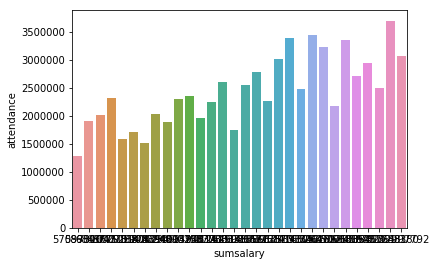

```python
# in ration table have the teamID, yearID, and attendance,
# in salary table, have the summed salary in given year
# then combine them to a table and plot attendace against salary
ratio=pd.read_sql("SELECT yearID, teamID,attendance FROM Teams WHERE yearID= 2016  ORDER BY yearID,teamID;", db)
salary=pd.read_sql("SELECT  SUM(salary) AS sumsalary FROM Salaries WHERE yearID= 2016 GROUP BY yearID,teamID ORDER BY yearID,teamID;", db)
table= pd.concat([ratio, salary], axis=1, sort=False)
sns.barplot("sumsalary","attendance",data=table.sort_values('sumsalary'))
```

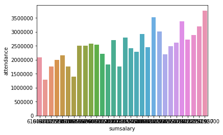

```python
# in ration table have the teamID, yearID, and attendance,
# in salary table, have the summed salary in given year
# then combine them to a table and plot attendace against salary
ratio=pd.read_sql("SELECT yearID, teamID,attendance FROM Teams WHERE yearID= 2015  ORDER BY yearID,teamID;", db)
salary=pd.read_sql("SELECT  SUM(salary) AS sumsalary FROM Salaries WHERE yearID= 2015 GROUP BY yearID,teamID ORDER BY yearID,teamID;", db)
table= pd.concat([ratio, salary], axis=1, sort=False)
sns.barplot("sumsalary","attendance",data=table.sort_values('sumsalary'))
```

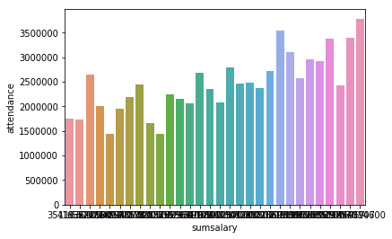

```python
# in ration table have the teamID, yearID, and attendance,
# in salary table, have the summed salary in given year
# then combine them to a table and plot attendace against salary
ratio=pd.read_sql("SELECT yearID, teamID,attendance FROM Teams WHERE yearID= 2014  ORDER BY yearID,teamID;", db)
salary=pd.read_sql("SELECT  SUM(salary) AS sumsalary FROM Salaries WHERE yearID= 2014 GROUP BY yearID,teamID ORDER BY yearID,teamID;", db)
table= pd.concat([ratio, salary], axis=1, sort=False)
sns.barplot("sumsalary","attendance",data=table.sort_values('sumsalary'))
```

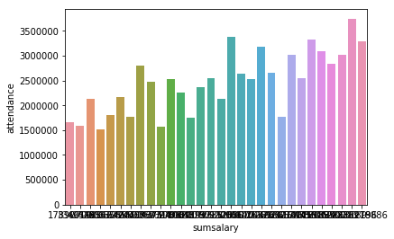

```python
# in ration table have the teamID, yearID, and attendance,
# in salary table, have the summed salary in given year
# then combine them to a table and plot attendace against salary
ratio=pd.read_sql("SELECT yearID, teamID,attendance FROM Teams WHERE yearID= 2013 ORDER BY yearID,teamID;", db)
salary=pd.read_sql("SELECT  SUM(salary) AS sumsalary FROM Salaries WHERE yearID= 2013 GROUP BY yearID,teamID ORDER BY yearID,teamID;", db)
table= pd.concat([ratio, salary], axis=1, sort=False)
sns.barplot("sumsalary","attendance",data=table.sort_values('sumsalary'))
```

# 1.1.4

from the plot we can see the attendence and total salary have positive corolation. the top 5 teams have higher attendenct compaire to other teams.

**Exercise 1.2.** Ask and use the database to answer 3 questions about baseball. For each question, write at least 2-3 paragraphs (~150 words) and support your answer with plots. If you feel like you don't have enough to write for a question, you probably aren't investigating follow up questions (inspired your original question) as carefully as you should.

**Try to come up with your own questions**, but here are two examples of reasonable questions:

- Is it common for players to switch teams? Has this changed over time? Which players have been on the most teams, and how many were they on?
- How much have salaries increased over the years in real dollars)? The `salary` column in the `Salaries` table is in nominal dollars, so you will need to get Consumer Price Index data online if you want to answer this question. Is there a corresponding increase in performance?

Please make sure to clearly state each of your questions in your submission.

# 1.2.1

Does the team with higher win/lose ration have higher salary?

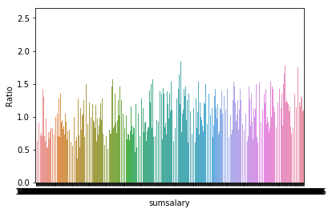

```python
# in ration table have the teamID, yearID, and win loss ratio,
# in salary table, have the summed salary in given year
# then combine them to a table and plot ratio against salary
ratio=pd.read_sql("SELECT yearID, teamID,W*1.00/L AS Ratio FROM Teams WHERE yearID BETWEEN 2000 AND 2016 ORDER BY yearID,teamID;", db)
salary=pd.read_sql("SELECT  SUM(salary) AS sumsalary FROM Salaries WHERE yearID BETWEEN 2000 AND 2016 GROUP BY yearID,teamID ORDER BY yearID,teamID;", db)
table= pd.concat([ratio, salary], axis=1, sort=False)
sns.barplot("sumsalary","Ratio",data=table.sort_values('sumsalary'))
```

```
I am interested in whether a higher salary will let the team have a higher win rate. I use win divide by losing as the subject to compare as y index, summed salary as x index. The time range between 2000 and 2016. I didn't choose to use earlier data because of the inflation
From the plot, we didn't see the pattern of higher salary cause the higher win rate. The graph has upward sloping is casued by the year. As the bars towerd to the right, mean the team with higher salary, by on the y axes, is doesn't show the higher win rate.
```

# 1.2.2

dose Managers' performanec have a pattern

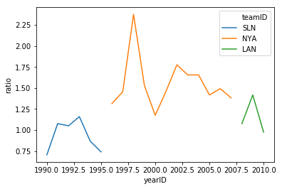

```python
#plot manager 'torrejo01's team performance form 1990 to 2010,win loss ratio as index
table1=pd.read_sql("SELECT W*1.00/L as ratio, * FROM Managers Where yearID BETWEEN 1990 AND 2016 AND playerID='torrejo01' ORDER BY yearID", db)
sns.lineplot("yearID","ratio",hue = "teamID",data=table1)
```

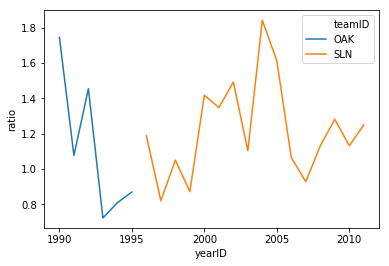

```python
#plot manager 'larusto01s team performance form 1990 to 2010,win loss ratio as index
table2=pd.read_sql("SELECT W*1.00/L as ratio, * FROM Managers Where yearID BETWEEN 1990 AND 2016 AND playerID='larusto01' ORDER BY yearID", db)
sns.lineplot("yearID","ratio",hue = "teamID",data=table2)
```

```python
#plot manager 'larusto01s team performance form 1990 to 2010,win loss ratio as index
table3=pd.read_sql("SELECT W*1.00/L as ratio, * FROM Managers Where yearID BETWEEN 1990 AND 2016 AND playerID='pinielo01' ORDER BY yearID", db)
sns.lineplot("yearID","ratio",hue = "teamID",data=table3)
```

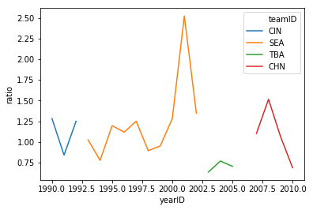

```python
sns.lineplot("yearID","ratio",hue = "teamID",data=table3)
```

```
I choosed 'pinielo01','larusto01','torrejo01' as the sample to study. they all work as a manager for a long time as working in framers team.Still, I use win/loss ratio as the stander.
I found 2 interesting things. The first thing is they work as a manager, their teams do have a pattern. When a team perfoms better year by year, the next year may still perfoms well, until it shows up a peak and starts to decline. The secound thing is the pattern of the perfomence of a manager keep constant even when they change the team.
```

# 1.2.3

I am interested in how age effect a player's salary

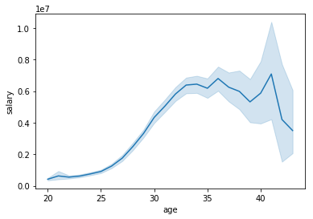

```python
right=pd.read_sql("SELECT playerID,yearID,salary FROM Salaries Where yearID BETWEEN 2006 AND 2016;", db)#table from Salary
left=pd.read_sql("SELECT playerID, birthYear FROM People Where birthYear > 1970 ORDER BY playerID;", db)#get age from Player table
tbe=pd.merge(left, right, on='playerID', how='outer')#combine tables
tb=tbe.dropna()# drop NAN
tb['age']=tb['yearID']-tb['birthYear']#add age
sns.lineplot("age","salary",data=tb)#plot age to salary
```

```
I add a column as age to the salary table, and plot the age to salary get the above plot. From the plot we can see, for baseall players, the salary increase slowly from age 20 to 26. Between age 26 to 36, salary increas in a faster way and reach the first peak at 36. After that, the variance of salary become bigger, some player's could keep increase, but some players's salary begin to decrease.On average, they reach the 2nd peak around 42, then all begin to decrease.
Baseball player's life on the play ground seems longer than other sport plays.They still can play unitl 40. This supresased me.
```